# class_4_lab

Thomas Zwiller

2025-03-26

**1. Loading the igraph package**

```r
#Loading the libraries I need
library(igraph)
library(ggraph)
```

**2. Loading in the ego-centric data**

```r
#Importing the node and edge csvs
nodes <- read.csv("/Users/TomTheIntern/Desktop/Mendoza/Mod 4/Networks/Lab 2/nodelist.csv")
summary(nodes)
```

```
##        ID            Name                Age           Gender
##  Min.   : 1.00   Length:12          Min.   :21.00   Length:12
##  1st Qu.: 3.75   Class :character   1st Qu.:23.00   Class :character
##  Median : 6.50   Mode  :character   Median :36.50   Mode  :character
##  Mean   : 6.50                      Mean   :38.00
##  3rd Qu.: 9.25                      3rd Qu.:45.75
##  Max.   :12.00                      Max.   :65.00
```

```r
edges <- read.csv('/Users/TomTheIntern/Desktop/Mendoza/Mod 4/Networks/Lab 2/edgelist.csv')
summary(edges)
```

```
##     ego_num         alter_num          ego               alter
##  Min.   : 1.000   Min.   : 1.000   Length:40          Length:40
##  1st Qu.: 2.750   1st Qu.: 2.750   Class :character   Class :character
##  Median : 5.000   Median : 5.000   Mode  :character   Mode  :character
##  Mean   : 5.575   Mean   : 5.575
##  3rd Qu.: 9.000   3rd Qu.: 9.000
##  Max.   :12.000   Max.   :12.000
##      type              strength
##  Length:40          Min.   :1.00
##  Class :character   1st Qu.:2.00
##  Mode  :character   Median :4.00
##                     Mean   :3.45
##                     3rd Qu.:4.25
##                     Max.   :5.00
```

**3 Creating the igraph object**

```r
#making the directed igraph
net <- graph_from_data_frame(edges, directed = T, vertices = nodes)
net
```

```
## IGRAPH 155eb6a DN-- 12 40 --
## + attr: name (v/c), Name (v/c), Age (v/n), Gender (v/c), ego (e/c),
## | alter (e/c), type (e/c), strength (e/n)
## + edges from 155eb6a (vertex names):
##  [1] 1 ->2  2 ->1  1 ->5  5 ->1  1 ->3  3 ->1  1 ->4  4 ->1  1 ->6  6 ->1
## [11] 1 ->7  7 ->1  1 ->10 10->1  2 ->4  4 ->2  2 ->3  3 ->2  4 ->3  3 ->4
## [21] 4 ->6  6 ->4  4 ->5  5 ->4  3 ->5  5 ->3  10->9  9 ->10 10->11 11->10
## [31] 10->12 12->10 9 ->12 12->9  11->12 12->11 6 ->7  7 ->6  7 ->8  8 ->7
```

```r
#making the un-directed igraph
un_net <- graph_from_data_frame(edges, directed = F, vertices = nodes)
un_net
```

```
## IGRAPH b424c8d UN-- 12 40 --
## + attr: name (v/c), Name (v/c), Age (v/n), Gender (v/c), ego (e/c),
## | alter (e/c), type (e/c), strength (e/n)
## + edges from b424c8d (vertex names):
##  [1] 1 --2  1 --2  1 --5  1 --5  1 --3  1 --3  1 --4  1 --4  1 --6  1 --6
## [11] 1 --7  1 --7  1 --10 1 --10 2 --4  2 --4  2 --3  2 --3  3 --4  3 --4
## [21] 4 --6  4 --6  4 --5  4 --5  3 --5  3 --5  9 --10 9 --10 10--11 10--11
## [31] 10--12 10--12 9 --12 9 --12 11--12 11--12 6 --7  6 --7  7 --8  7 --8
```

**4. Choose two centrality measures and apply them to your network** I am using Degree and Eigenvector as my two centrality measures

**5. Visualize your network (one graph for each measure) with node size representing your chosen measures**

**Degree**

```
## Using "stress" as default layout
```

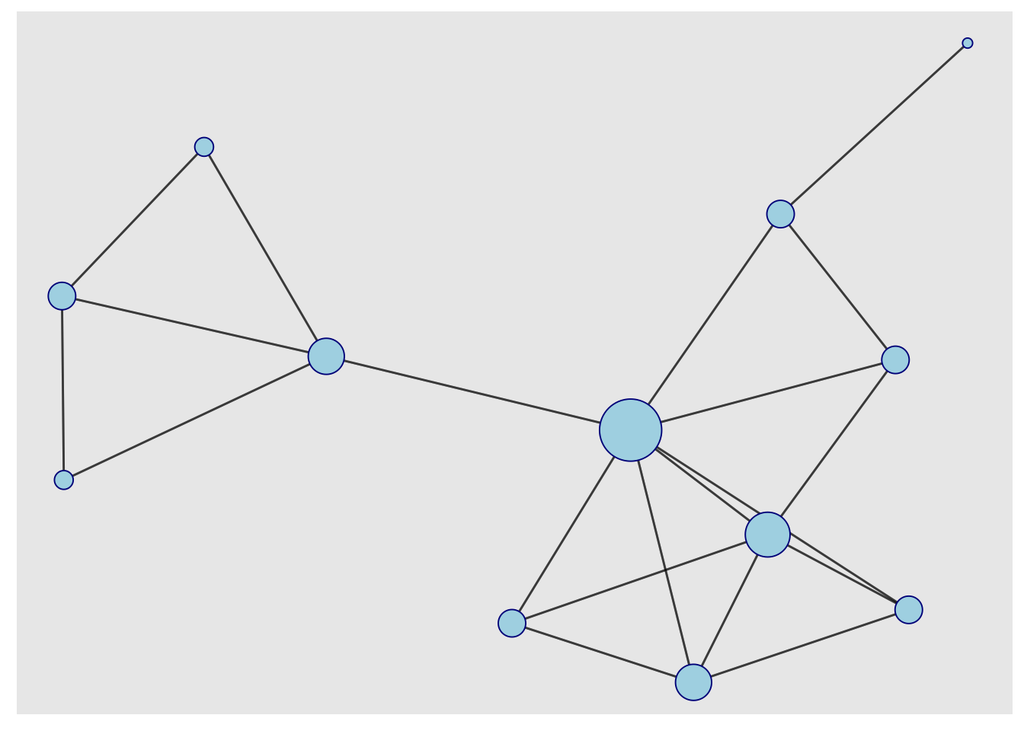

```r
ggraph(net) +
  geom_edge_link0(color = "black", alpha = .5) +
  geom_node_point(fill = "lightblue", color = "darkblue", shape = 21,
                  size = igraph::degree(net, mode = "all"))
```

**Eigenvector**

```
## Using "stress" as default layout
```

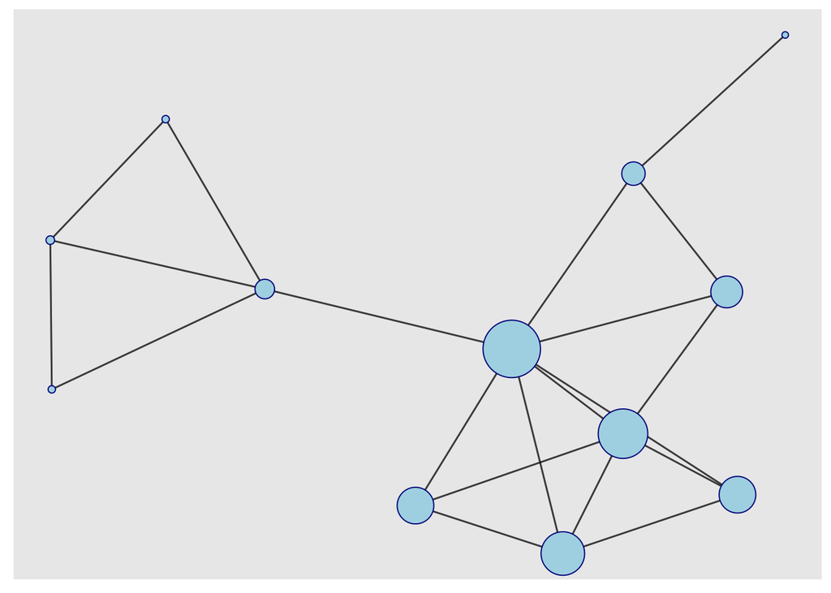

```r
ggraph(un_net) +
  geom_edge_link(color = "black", alpha = .5) +
  geom_node_point(fill = "lightblue", color = "darkblue", shape = 21,
                  size = igraph::eigen_centrality(un_net)$vector*16)
```

**6. Describe what the measure tells you about the people in your network**

**What Degree tells me about the people in my network** Unsurprisingly, I had the most degrees, which made my node the biggest. Generally, the different communities were relatively the same size:

the football network (my co-workers) were all consistent because they were connected. my girlfriend’s family generally tended to be smaller, as they only had 2-3 connections compared to football having 4-5

my res-life coworkers were the smallest, with my co-workers girlfriend having just one connection, making it the smallest, and about as close to an isolet as possible.

**What Eigenvector tells me about the people in my network**

The Eigenvector measure looks relatively similar to the degree measure, though there are a few key differences. My girlfriend has a much bigger circle in the nodes, but because most of her connections were to other relatively un-connected nodes, she had a smaller representation.

Comparatively, the football network was actually bigger because they all knew me, and each other, which helped improve their score.

My res-life co-workers were relatively smaller than their node score, however my co-worker who works with the ND bad (and would theoretically know Marcus Freeman) had a bit of a higher score.